# Part 1

### Improving the accuracy of the Euler method

**Q9: Reduce the time step at which *model1_Euler_V1.stan* solves the ODEs to improve the accuracy of the fit**

**A9: *m1_EU2* shows how to modify the original model to allow us to estimate the ODE solutions at a scaled time step, which is smaller than 1 day. We now just need to provide an additional data variable, the amount to scale by.**

**Within the model, we also need to divide all the *rate* parameters by our scaling factor, as $\sigma$ and $\gamma$ are in days. We do this in the transformed data block.**

**Once we have solved the model at our desired resolution, we need to aggregate the reported incidence back into days which is done in the model block. The way we do this is using a for loop which adds to the index as it runs**

```r
# run the model

stan_fit_EU2 = run_stan_models(
  list_data =
    list(
      n_ts = length(all_dates),         # no. time steps
      n_pop = n_pop,                    # population
      n_recov = n_recov,                # recovered population
      y = sim_inc$rep_inc,              # incidence data
      n_data = dim(sim_inc)[1],         # no. data
      sigma = sigma,                    # progression rate
      gamma = gamma,                    # recovery rate
      time_seed_omicron =               # index seed omicron
        which(all_dates == seed_omicron),
      scale_time_step = 5               # amount to reduce time step
    ),
  model = m1_EU2
)
```

```
## Time difference of 9.632528 mins
```

**Even reducing the step size by a factor of 5-fold, the run time is ~3x faster than the RK method.**

**Let’s check the diagnostics now and see if we are able to improve the accuracy.**

```r
EU2_diag = diagnose_stan_fit(stan_fit_EU2, pars = c("beta", "rho", "I0"))
```

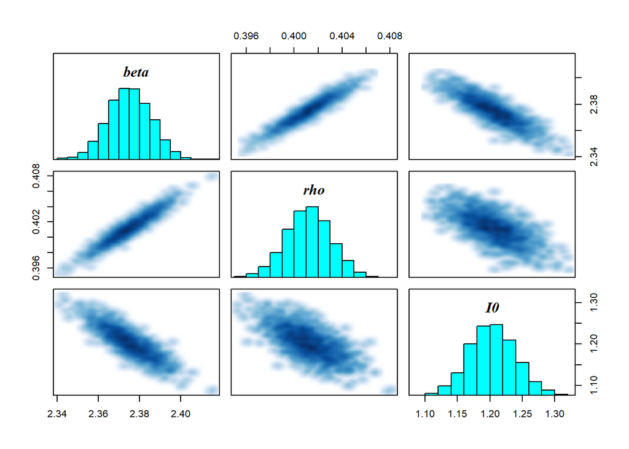

```r
EU2_diag
```

```
## $`markov chain trace plots`
```

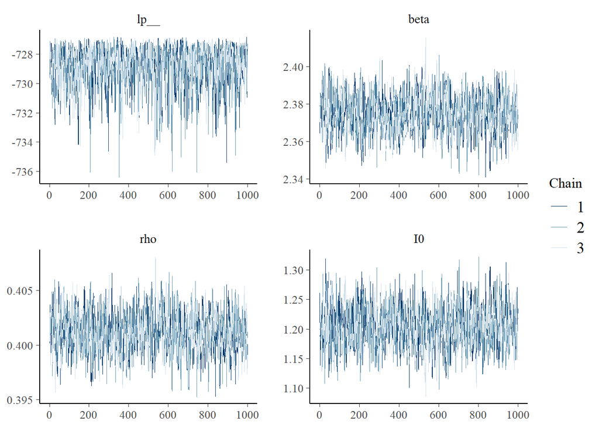

```
##
## $`univariate marginal posterior distributions`
```

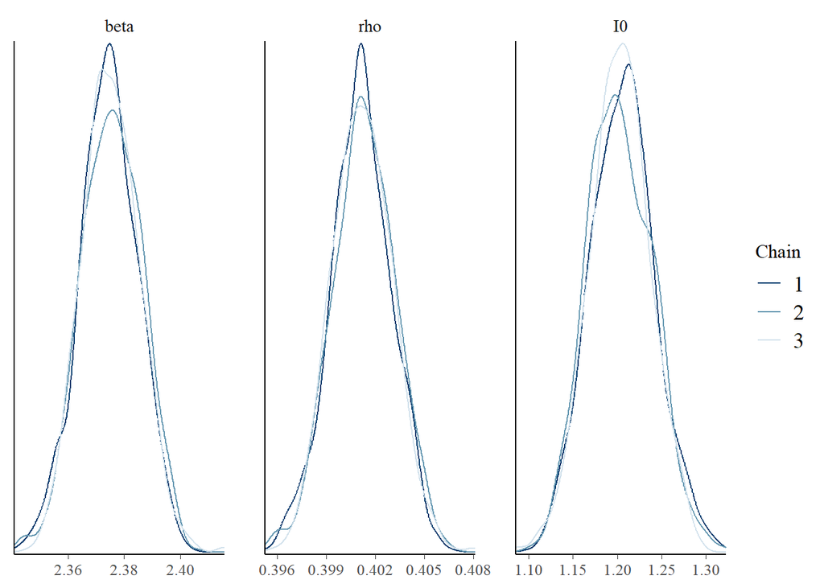

```
##
## $`summary statistics of parameters`
##           mean      se_mean         sd      2.5%       25%       50%       75%
## beta 2.3750736 3.607541e-04 0.01035894 2.3547861 2.3680540 2.3750302 2.3823462
## rho  0.4012047 6.130699e-05 0.00186027 0.3975801 0.3999485 0.4011833 0.4024708
## I0   1.2039373 1.178490e-03 0.03559785 1.1355779 1.1793595 1.2033568 1.2277820
##          97.5%    n_eff     Rhat
## beta 2.3949911 824.5333 1.000922
## rho  0.4047989 920.7295 1.000693
## I0   1.2765703 912.4221 1.000638
```

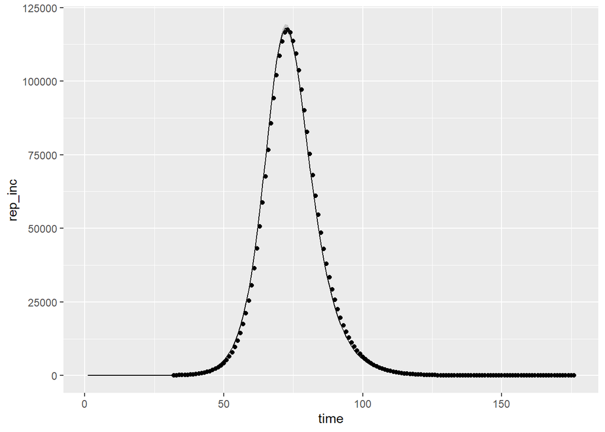

```r
EU2_plot = plot_model_fit(stan_fit_EU2, "lambda_days", "rep_inc", sim_inc)

EU2_plot
```

**Finally, lets compare parameter estimates again**

```r
compare_param_est(
  parameter_names = c("beta", "rho", "I0"),
  true_param_values = c(beta, rho, n_inf),
  param_values1 =  EU2_diag[[3]][,c(1,4,8)],
  param_values2 =  RK_diag[[3]][,c(1,4,8)]
)
```

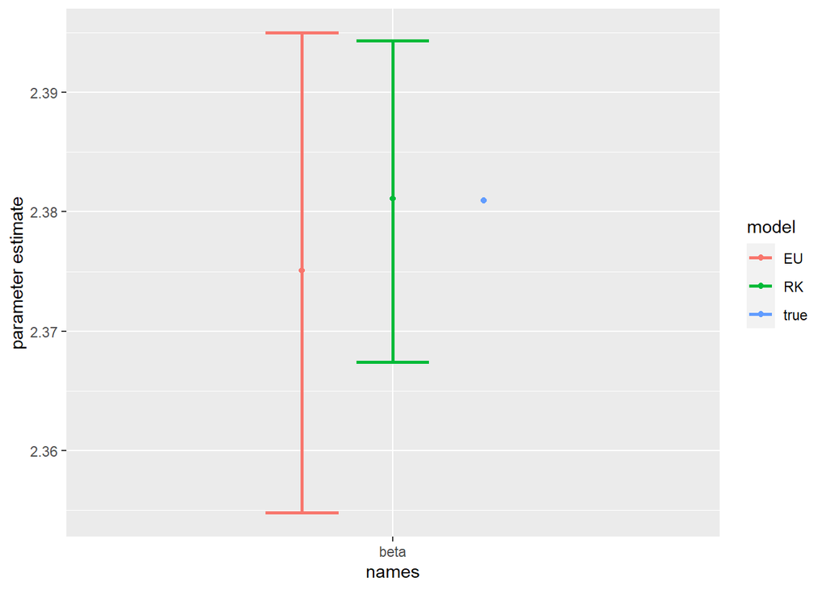

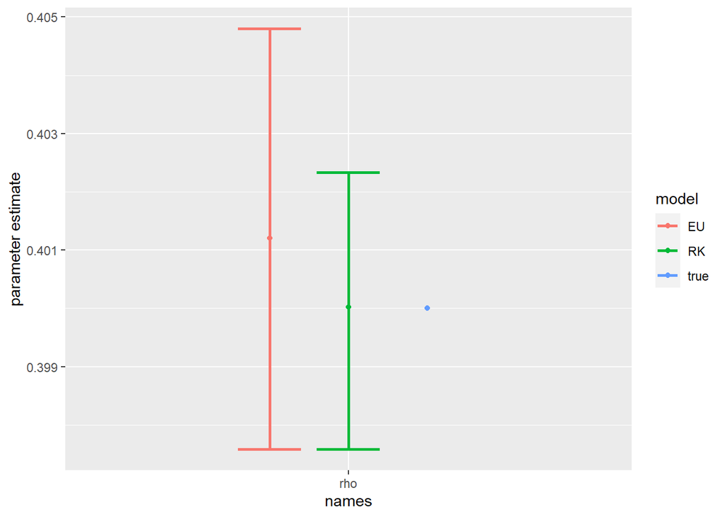

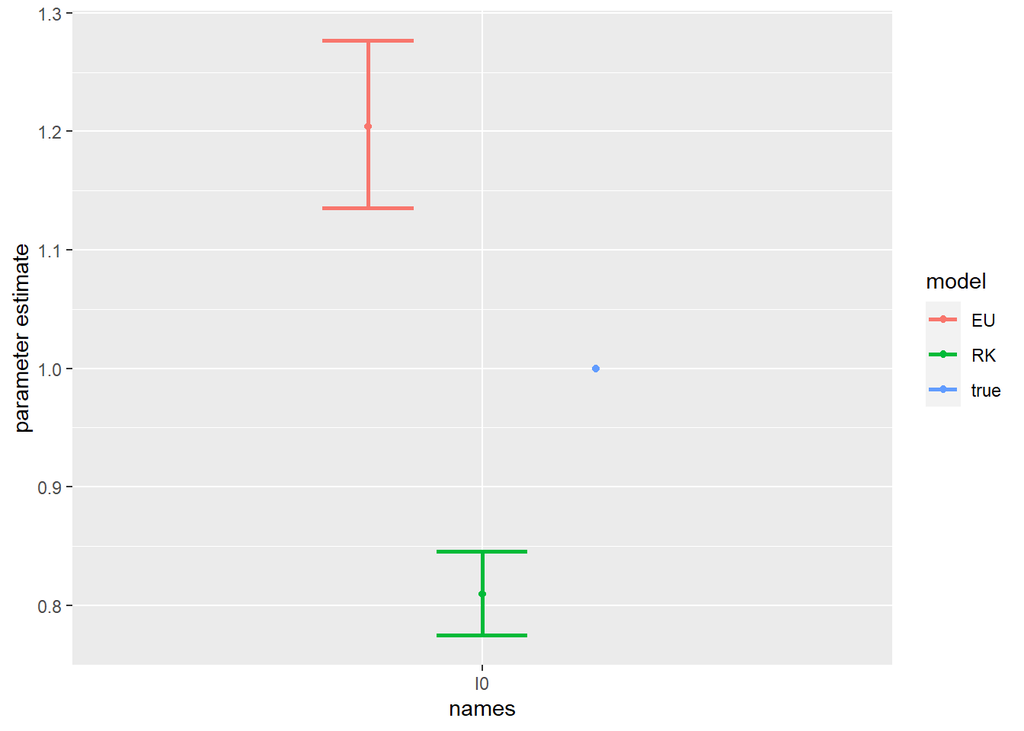

# Fitting to real data

Now that we are confident in our models fitting to simulated data, lets fit to real observed data! As mentioned above, we are initially going to assume that all reported incidence during the modelling period in Gauteng is Omicron.

**Q10: fit *model1_EU2* to the real data. The *raw_data* is provided for all districts of South Africa between 05-03-2020 and 08-06-2022. The column GP refers to Gauteng. The data provided is cumulative so you will need to convert to daily incidence data. N.b. make sure to use the second version of the Euler model, where we reduce the time step to improve accuracy**

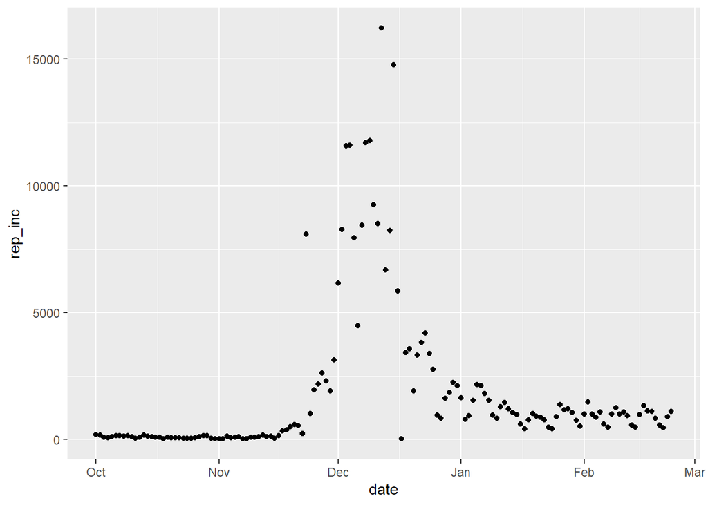

```r
obs_inc = tidy_obs_inc(
              raw_data = raw_data,
              date_seed = seed_omicron,
              end_date = end_date
              )

ggplot(obs_inc, aes(x=date, y=rep_inc)) +
     geom_point()
```

**Fit the model to the observed data**

```r
stan_fit_EU2_obs = run_stan_models(
  list_data =
    list(
      n_ts = length(all_dates),         # no. time steps
      n_pop = n_pop,                    # population
      n_recov = n_recov,                # recovered population
      y = obs_inc$rep_inc,              # incidence data
      n_data = dim(obs_inc)[1],         # no. data
      sigma = sigma,                    # progression rate
      gamma = gamma,                    # recovery rate
      time_seed_omicron =               # index seed omicron
        which(all_dates == seed_omicron),
      scale_time_step = 5               # amount to reduce time step
    ),
  model = m1_EU2
)
```

```
## Time difference of 24.41767 mins
```

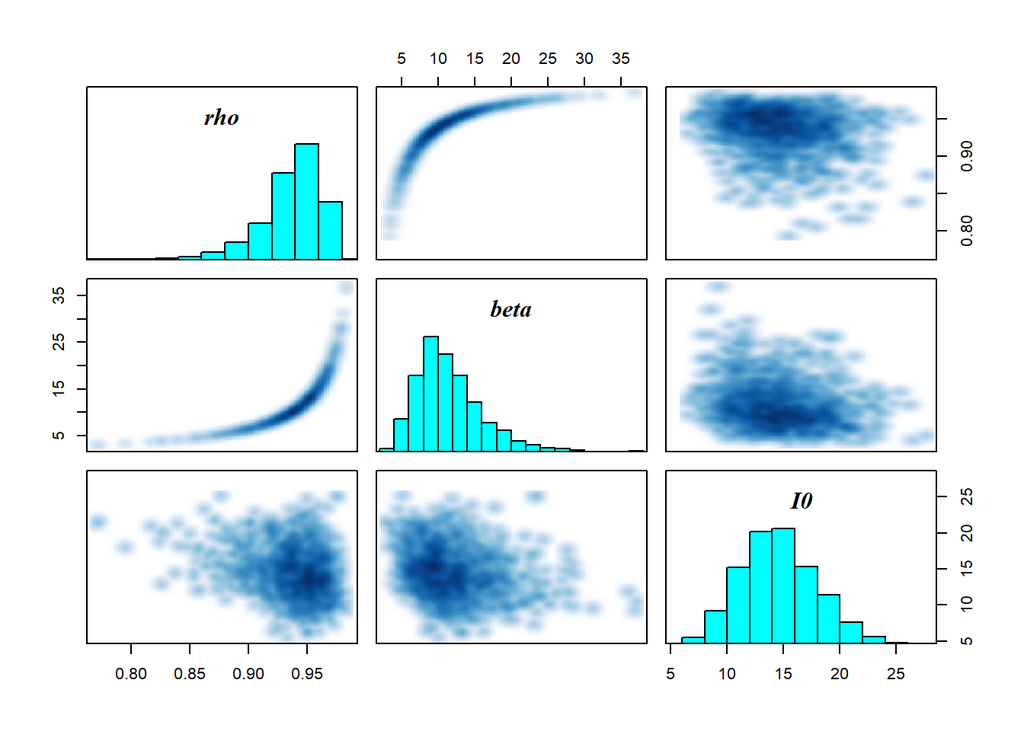

```
## $`markov chain trace plots`
```

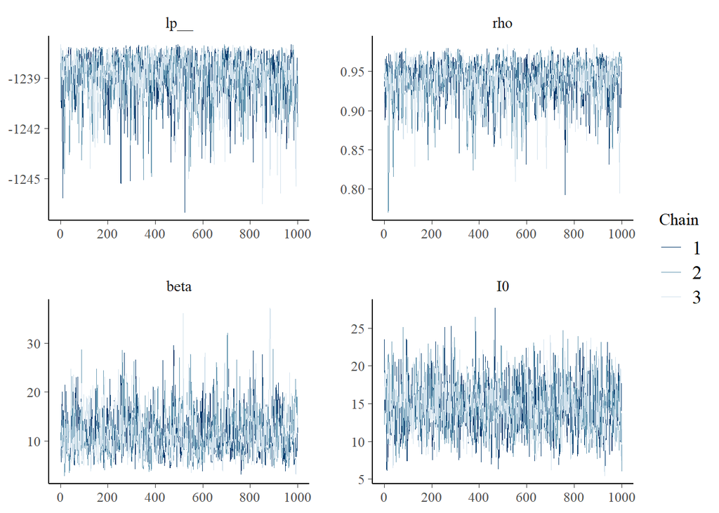

```
##
## $`univariate marginal posterior distributions`
```

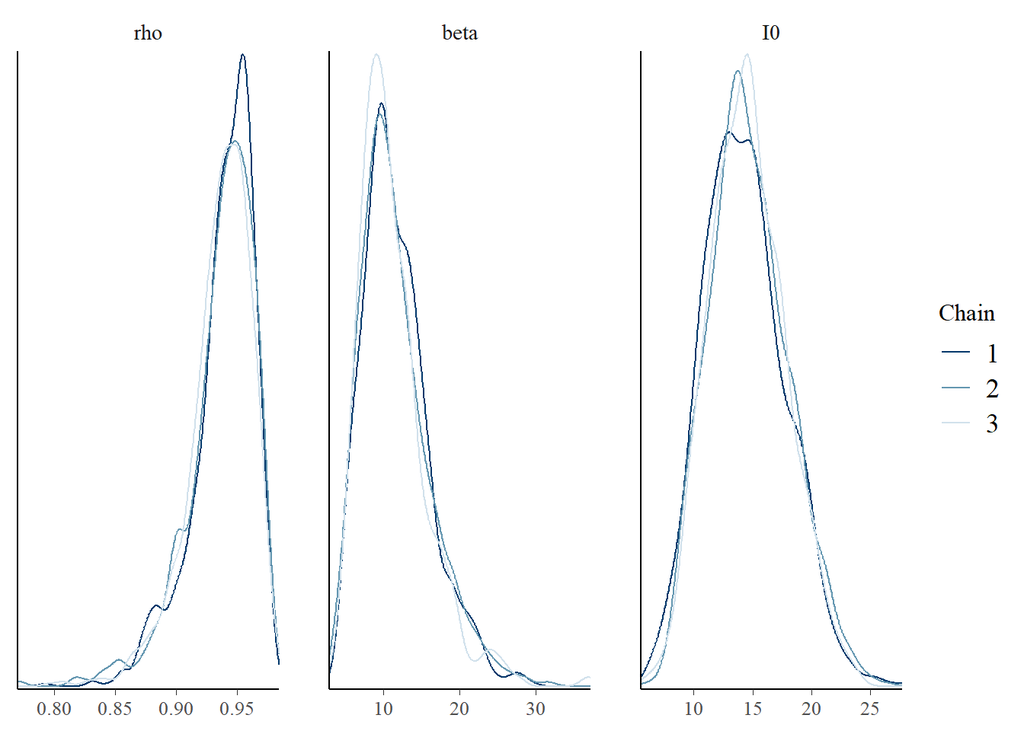

```
##
## $`summary statistics of parameters`
##            mean      se_mean         sd      2.5%        25%        50%
## rho   0.9371493 0.0009034013 0.02675578 0.8713797  0.9248258  0.9417736
## beta 11.5232973 0.1433768616 4.52926411 5.0634184  8.3678000 10.6750179
## I0   14.5438848 0.0850630267 3.33688350 8.6372147 12.1571181 14.3503821
##             75%      97.5%     n_eff     Rhat
## rho   0.9558474  0.9740392  877.1501 1.002800
## beta 13.7654191 22.6811226  997.9233 1.001916
## I0   16.7349255 21.3864803 1538.8647 1.001967
```

```r
diagnose_stan_fit(
  stan_fit_EU2_obs, #
  pars = c("rho", "beta", "I0"))
```

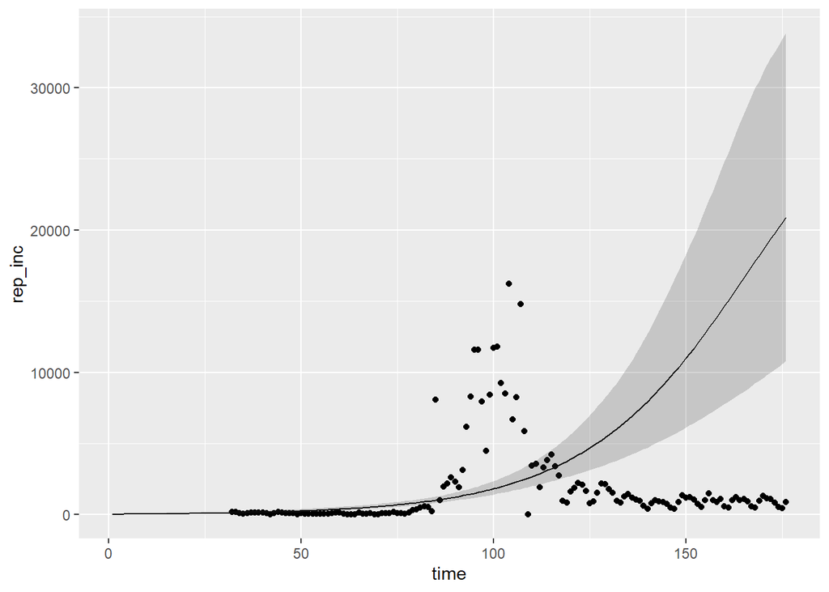

```r
plot_model_fit(
  stan_fit_EU2_obs,
  variable_model = "lambda_days",
  variable_data  = "rep_inc",
  data = obs_inc,
  date_seed  = seed_omicron
)
```

So, if you fit the model to the observed data you should find that even though there were no model warnings and the chains have converged, the model is not fitting the data at all.

Looking at the parameter values, the model is converging on posterior distributions with very high $\rho$ values indicating almost all infected individuals are tested and isolate. Intuitively, we can imagine this is probably unlikely. Moreover, a sero-survey from Gauteng, South Africa estimated a 2-20 fold underreporting of cases, corresponding to a reporting rate <50% [5]. Therefore, lets amend the prior on $\rho$ to reflect this prior information. *m1_EU3* has an updated $\rho$ prior: $\rho \sim Beta(1,4)$. Let’s rerun the model to see if this improves things.

```r
stan_fit_EU3_obs = run_stan_models(
  list_data =
    list(
      n_ts = length(all_dates),         # no. time steps
      n_pop = n_pop,                    # population
      n_recov = n_recov,                # recovered population
      y = obs_inc$rep_inc,              # incidence data
      n_data = dim(obs_inc)[1],         # no. data
      sigma = sigma,                    # progression rate
      gamma = gamma,                    # recovery rate
      time_seed_omicron =               # index seed omicron
        which(all_dates == seed_omicron),
      scale_time_step = 5               # amount to reduce time step
    ),
  model = m1_EU3
)
```

```
## Warning: There were 1 chains where the estimated Bayesian Fraction of Missing Information was low. See
## https://mc-stan.org/misc/warnings.html#bfmi-low
```

```
## Warning: Examine the pairs() plot to diagnose sampling problems
```

```
## Time difference of 17.37883 mins
```

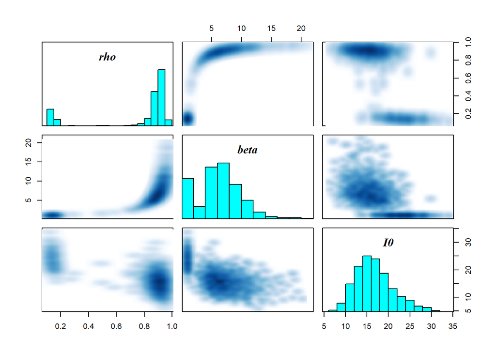

```
## $`markov chain trace plots`
```

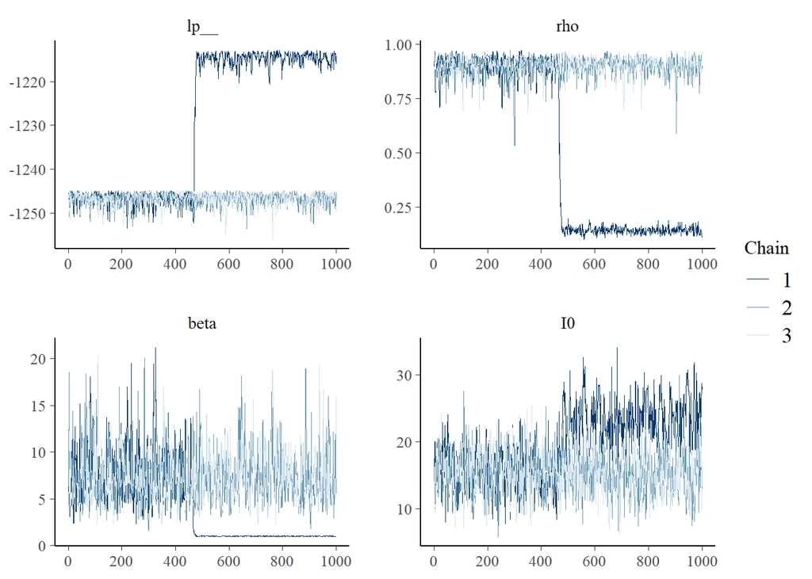

```
##
## $`univariate marginal posterior distributions`
```

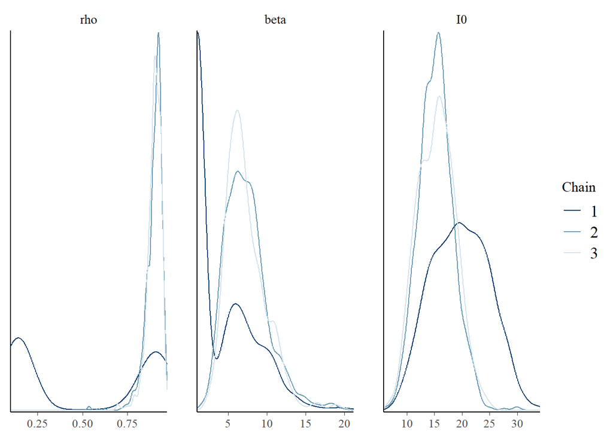

```
##
## $`summary statistics of parameters`
##            mean   se_mean        sd      2.5%        25%       50%        75%
## rho   0.7653164 0.1389601 0.2918762 0.1248983  0.8452302  0.896459  0.9249498
## beta  6.2726090 1.1150043 3.5458580 1.0009972  4.2795871  6.227198  8.3991281
## I0   16.7974948 1.5107162 4.4712760 9.5110392 13.5916723 16.212817 19.2706747
##           97.5%     n_eff     Rhat
## rho   0.9548079  4.411811 3.794325
## beta 13.5591202 10.113223 1.391498
## I0   27.4335603  8.759860 1.396614
```

```r
diagnose_stan_fit(
  stan_fit_EU3_obs, #
  pars = c("rho", "beta", "I0"))
```

Looking at the model fit, we can see it is starting to fit the data, indicating we are on the right path.

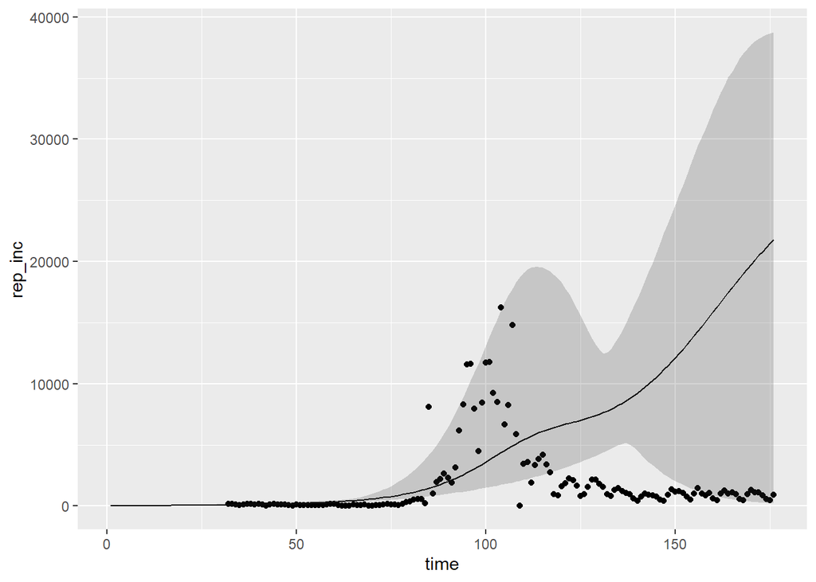

```r
plot_model_fit(
  stan_fit_EU3_obs,
  variable_model = "lambda_days",
  variable_data  = "rep_inc",
  data = obs_inc,
  date_seed  = seed_omicron
)
```

Let’s rerun the model for longer and also relax the prior on the number of initial infections; $I_{t0} \sim ND(1,50)$.

```r
stan_fit_EU4_obs = run_stan_models(
  list_data =
    list(
      n_ts = length(all_dates),         # no. time steps
      n_pop = n_pop,                    # population
      n_recov = n_recov,                # recovered population
      y = obs_inc$rep_inc,              # incidence data
      n_data = dim(obs_inc)[1],         # no. data
      sigma = sigma,                    # progression rate
      gamma = gamma,                    # recovery rate
      time_seed_omicron =               # index seed omicron
        which(all_dates == seed_omicron),
      scale_time_step = 5               # amount to reduce time step
    ),
  model = m1_EU4,
  n_iter = 3000,
  n_warmup = 1500
)
```

```
## Time difference of 7.234804 mins
```

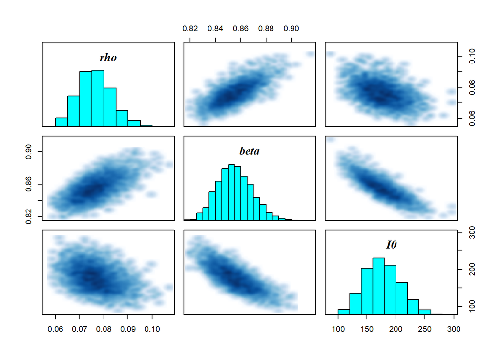

```
## $`markov chain trace plots`
```

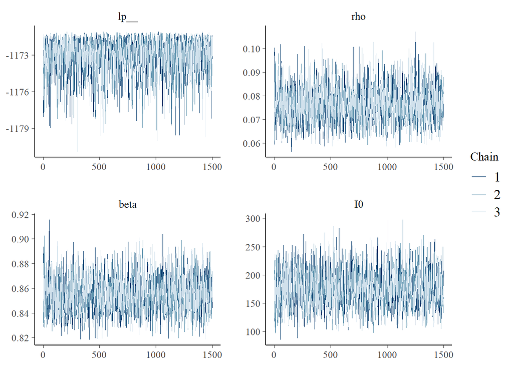

```
##
## $`univariate marginal posterior distributions`
```

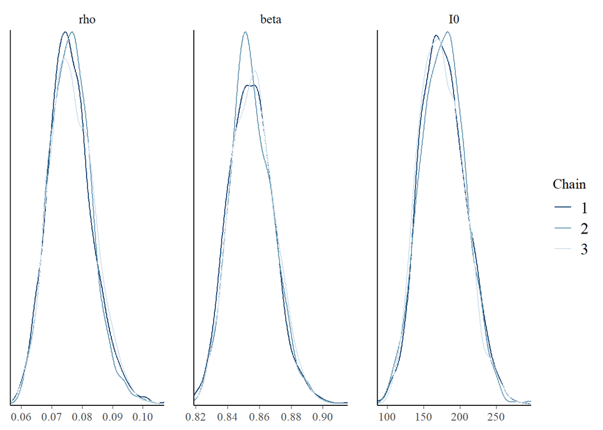

```
##
## $`summary statistics of parameters`
##              mean      se_mean           sd         2.5%          25%
## rho    0.07637631 0.0001459956  0.007126079   0.06336029   0.07139853
## beta   0.85528969 0.0003176128  0.013658431   0.83020035   0.84563304
## I0   176.37854723 0.6670595056 30.603731421 120.99386007 154.36843764
##               50%          75%        97.5%    n_eff     Rhat
## rho    0.07593078   0.08097129   0.09180511 2382.438 1.002502
## beta   0.85455851   0.86429209   0.88409235 1849.293 1.002390
## I0   175.00788816 196.78905997 239.32231710 2104.843 1.000880
```

```r
diagnose_stan_fit(
  stan_fit_EU4_obs, #
  pars = c("rho", "beta", "I0"))
```

No warnings and the diagnostic plots look good.

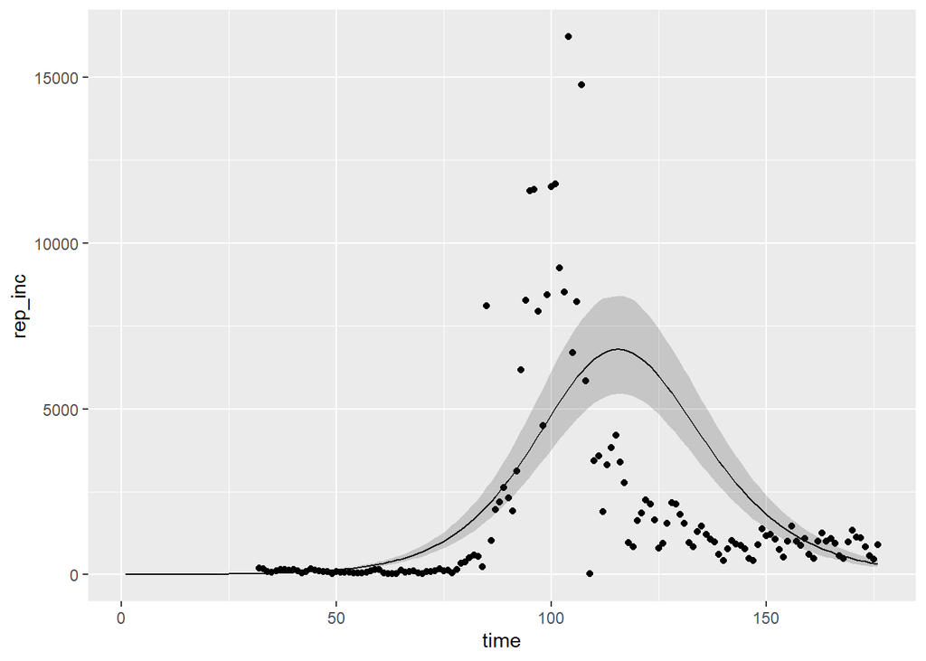

```r
plot_model_fit(
  stan_fit_EU4_obs,
  variable_model = "lambda_days",
  variable_data  = "rep_inc",
  data = obs_inc,
  date_seed  = seed_omicron
)
```

The model fitting is better, although it is still not capturing the timing or height of the peak.

**Bonus activity: See if you can improve the model fit further. You could try seeing the model earlier and later than 1 month, to see if that helps!**

The alternative is to revisit some of our assumptions. Perhaps we not able to capture the transmission dynamics of Omicron because we are missing vital aspects from our model. In part 2 we will account for this by fitting the model to multiple variants, not just Omicron, capturing the transmission dynamics over a longer time period and accounting for vaccination and interventions as well! See you there.

# References

- 1. Madhi SA, Kwatra G, Myers JE, et al. Population Immunity and Covid-19 Severity with Omicron Variant in South Africa. N Engl J Med 2022; 386(14): 1314-26.
- 2. Lavezzo E, Franchin E, Ciavarella C, et al. Suppression of a SARS-CoV-2 outbreak in the Italian municipality of Vo’. Nature 2020; 584(7821): 425-9.
- 3. McAloon C, Collins Á, Hunt K, et al. Incubation period of COVID-19: a rapid systematic review and meta-analysis of observational research. BMJ Open 2020; 10(8): e039652.
- 4. Liu, Y. & Rocklov, J. The reproductive number of the Delta variant of SARS-CoV-2 is far higher compared to the ancestral SARS-CoV-2 virus. J Travel Med 28, doi:10.1093/jtm/taab124 (2021).
- 5. Mutevedzi, P. C. et al. Estimated SARS-CoV-2 infection rate and fatality risk in Gauteng Province, South Africa: a population-based seroepidemiological survey. Int J Epidemiol 51, 404-417, doi:10.1093/ije/dyab217 (2022).